# What is Machine Learnings?

Machine Learning (ML) is a subset of artificial intelligence (AI) that focuses on the development of algorithms and statistical models that enable computer systems to perform tasks without explicit programming. The fundamental idea behind machine learning is to enable computers to learn from data and improve their performance over time.

In traditional programming, a human programmer writes explicit instructions for a computer to perform a specific task. However, in machine learning, the approach is different. Instead of providing explicit instructions, the system is trained on data, allowing it to learn patterns, make predictions, and improve its performance through experience.

Here are key concepts and components of machine learning:

1. **Data:** Machine learning algorithms rely on data to learn patterns and make predictions. The quality and quantity of the data significantly impact the performance of the model.
2. **Features:** Features are the individual measurable properties or characteristics of the data. In a dataset, each row represents an observation, and each column represents a feature.
3. **Labels/Targets:** In supervised learning, the algorithm is trained on a labeled dataset, where the desired output (or target) is provided along with the input data. The algorithm learns to map inputs to outputs.
4. **Training:** During the training phase, the machine learning model is exposed to a dataset to learn the underlying patterns. The algorithm adjusts its internal parameters to minimize the difference between its predictions and the actual outcomes.
5. **Testing/Evaluation:** After training, the model is evaluated on a separate dataset to assess its performance and generalization to new, unseen data. This step helps ensure that the model has not simply memorized the training data but can make accurate predictions on new data.
6. **Types of Machine Learning:**
   - **Supervised Learning:** The algorithm is trained on a labeled dataset, and it learns to make predictions or classify new data based on the patterns learned during training.
   - **Unsupervised Learning:** The algorithm is given unlabeled data and must find patterns or relationships within the data without explicit guidance.
   - **Reinforcement Learning:** The algorithm learns by interacting with an environment and receiving feedback in the form of rewards or penalties. It aims to learn the optimal strategy to maximize cumulative rewards.
7. **Common Algorithms:**
   - **Linear Regression:** Predicts a continuous output based on input features.
   - **Decision Trees:** Tree-like models that make decisions based on input features.
   - **Neural Networks:** Complex models inspired by the structure of the human brain, particularly effective for tasks like image recognition and natural language processing.
   - **Support Vector Machines (SVM):** Classifies data by finding the hyperplane that best separates different classes.
8. **Applications:** Machine learning is applied in various domains, including image and speech recognition, natural language processing, recommendation systems, healthcare diagnostics, financial fraud detection, autonomous vehicles, and many more.

Machine learning is a dynamic and evolving field, with ongoing research and development continually expanding its applications and capabilities.

# Learning Algorithms?

A machine learning algorithm is an algorithm that is able to learn from data. But what do we mean by learning? Mitchell ( 1997) provides the definition “A computer program is said to learn from experience E with respect to some class of tasks T and performance measure P , if its performance at tasks in T , as measured by P , improves with experience E.” One can imagine a very wide variety of experiences E, tasks T , and performance measures P , and we do not make any attempt in this book to provide a formal definition of what may be used for each of these entities. Instead, the following sections provide intuitive descriptions and examples of the different kinds of tasks, performance measures and experiences that can be used to construct machine learning algorithms.

The concept of learning algorithms can be explained in terms of the Task (T), the Performance Measure (P), and the Experience (E). This framework is often referred to as the "Task-Performance-Experience" framework.

1. **Task (T):**
   - **Definition:** The task (T) represents what the learning system is trying to accomplish or the problem it is designed to solve.
   - **Example:** In the context of image recognition, the task could be to correctly classify images of digits as numbers from 0 to 9.
2. **Performance Measure (P):**
   - **Definition:** The performance measure (P) is a metric that quantifies how well the learning system is accomplishing the task. It is a measure of the system's success or failure in achieving its objectives.
   - **Example:** For an image recognition task, the performance measure could be the accuracy of the model in correctly classifying images.
3. **Experience (E):**
   - **Definition:** The experience (E) refers to the data or information that the learning system uses to learn and improve its performance on the task. It is the input the system receives to adapt and make better predictions or decisions.
   - **Example:** In supervised learning, the experience would be a dataset containing labeled examples of images, where each image is associated with the correct digit label.

Now, let's bring these concepts together:

- **Learning Algorithm:**
  - A learning algorithm is a computational procedure that takes the experience (E) as input and produces a hypothesis (H) as output.
  - The hypothesis (H) is the learned model or function that maps inputs to outputs, attempting to capture the underlying patterns in the data to perform the task.
- **Learning Process:**
  - The learning process involves the learning algorithm using the provided experience (E) to produce a hypothesis (H) that minimizes the discrepancy between its predictions and the actual outcomes.
  - The learning algorithm refines its internal parameters based on the feedback from the performance measure (P) to improve its ability to perform the task (T).
- **Iterative Nature:**
  - Learning is often an iterative process where the algorithm receives additional experience, refines its hypothesis, and adjusts its parameters to improve performance over time.

In summary, the learning algorithm takes in experience (E) to perform a specific task (T) and is evaluated based on a performance measure (P). The goal is to continually improve the hypothesis (H) or model to enhance its ability to successfully accomplish the task. This framework provides a systematic way to understand and evaluate the learning process in various machine learning applications.

## Task, T

Machine learning allows us to tackle tasks that are too difficult to solve with fixed programs written and designed by human beings. From a scientific and philosophical point of view, machine learning is interesting because developing our understanding of machine learning entails developing our understanding of the principles that underlie intelligence.

Machine learning can address a wide range of tasks, and these tasks are broadly categorized into different types based on the nature of the problem and the desired output. Here are some common types of machine learning tasks:

1. **Supervised Learning:**
   - **Classification:** In classification, the algorithm is trained on a labeled dataset where each example belongs to a certain category or class. The goal is to learn a mapping from inputs to predefined output classes.
     - Example: Spam detection, image classification, sentiment analysis.
   - **Regression:** In regression, the algorithm predicts a continuous output based on input features. The goal is to learn a mapping from inputs to a continuous numeric value.
     - Example: Predicting house prices, stock prices, temperature.
2. **Unsupervised Learning:**
   - **Clustering:** Clustering involves grouping similar data points together based on some similarity measure. The algorithm identifies patterns or relationships within the data without predefined categories.
     - Example: Customer segmentation, document clustering.
   - **Dimensionality Reduction:** Dimensionality reduction techniques aim to reduce the number of input features while preserving relevant information. This helps in visualizing and processing high-dimensional data.
     - Example: Principal Component Analysis (PCA), t-Distributed Stochastic Neighbor Embedding (t-SNE).
3. **Reinforcement Learning:**
   - Reinforcement learning involves an agent that interacts with an environment and learns to make decisions by receiving feedback in the form of rewards or penalties. The goal is to find an optimal strategy to maximize cumulative rewards over time.
     - Example: Game playing (e.g., AlphaGo), robotic control, autonomous vehicles.
4. **Semi-Supervised Learning:**
   - Semi-supervised learning combines elements of both supervised and unsupervised learning. The algorithm is trained on a dataset with both labeled and unlabeled examples. This is particularly useful when obtaining labeled data is expensive or time-consuming.
     - Example: Image recognition with limited labeled data.
5. **Self-Supervised Learning:**
   - Self-supervised learning is a type of unsupervised learning where the algorithm generates its own labels from the input data. This can involve predicting missing parts of the input or solving other auxiliary tasks.
     - Example: Word embeddings, image completion.
6. **Transfer Learning:**
   - Transfer learning involves training a model on one task and then applying the learned knowledge to a different, but related, task. This is especially useful when labeled data is scarce for the target task.
     - Example: Pre-training a model on a large image dataset and fine-tuning it for a specific image classification task.
7. **Association Rule Learning:**
   - Association rule learning discovers interesting relationships or associations among variables in large datasets. It identifies rules that describe how certain events tend to occur together.
     - Example: Market basket analysis in retail, recommendation systems.
8. **Generative Models:**
   - Generative models create new samples that resemble the training data. These models can be used for tasks like image generation, text-to-image synthesis, and data augmentation.
     - Example: Generative Adversarial Networks (GANs), Variational Autoencoders (VAEs).
9. **Sequence-to-Sequence Learning:**
   - Sequence-to-sequence learning involves mapping input sequences to output sequences, making it suitable for tasks where the input and output have a sequential or temporal relationship.
     - Example: Machine translation, speech recognition, text summarization.
10. **Time Series Forecasting:**
    - Time series forecasting focuses on predicting future values based on past observations. It involves understanding and modeling temporal dependencies in the data.
      - Example: Stock price prediction, weather forecasting, energy consumption prediction.
11. **Anomaly Detection:**
    - Anomaly detection aims to identify instances that deviate significantly from the norm in a dataset. It is valuable for detecting unusual patterns or outliers.
      - Example: Fraud detection, network intrusion detection, equipment failure prediction.
12. **Multi-Label Classification:**
    - In multi-label classification, each instance is assigned multiple labels simultaneously. This is different from traditional classification where each instance is assigned to a single category.
      - Example: Document categorization with multiple topics, image tagging.
13. **Multi-Task Learning:**
    - Multi-task learning involves training a model to perform multiple related tasks simultaneously. The goal is to leverage shared information across tasks to improve overall performance.
      - Example: Simultaneous learning of part-of-speech tagging and named entity recognition in natural language processing.
14. **Causal Inference:**
    - Causal inference aims to understand cause-and-effect relationships in data. It involves determining how changes in one variable affect another.
      - Example: Understanding the impact of a marketing campaign on sales, determining the effectiveness of a medical treatment.
15. **Fairness and Bias Mitigation:**
    - Fairness and bias mitigation in machine learning involve developing models that are fair and unbiased across different demographic groups. This is crucial to ensure ethical and equitable applications.
      - Example: Ensuring fairness in hiring algorithms, mitigating bias in credit scoring.

These task categories showcase the versatility of machine learning in addressing diverse challenges across various domains. Depending on the specific problem at hand, practitioners choose the most suitable task type and learning approach to achieve effective and ethical solutions. Machine learning continues to evolve, and researchers are exploring innovative ways to tackle new types of tasks and improve the robustness and interpretability of models.

# How We Measure Performance Of Machine Learning Algorithm?

Measuring the performance of machine learning algorithms is crucial to understanding how well they are solving a particular task. The choice of performance metrics depends on the type of task (classification, regression, clustering, etc.) and the specific goals of the application. Here are some common performance metrics for different types of machine learning tasks:

### 1. **Classification Metrics:**

- **Accuracy:** The proportion of correctly classified instances out of the total instances. It is suitable when the classes are balanced.
- **Precision:** The ratio of true positive predictions to the total predicted positives. It is a measure of the accuracy of positive predictions.
- **Recall (Sensitivity or True Positive Rate):** The ratio of true positive predictions to the total actual positives. It is a measure of how well the model identifies positive instances.
- **F1 Score:** The harmonic mean of precision and recall. It provides a balance between precision and recall.
- **Area Under the Receiver Operating Characteristic (ROC) Curve (AUC-ROC):** A metric that evaluates the ability of a binary classifier to discriminate between positive and negative instances across different probability thresholds.

### 2. **Regression Metrics:**

- **Mean Absolute Error (MAE):** The average absolute difference between the predicted and actual values. It is less sensitive to outliers.
- **Mean Squared Error (MSE):** The average of the squared differences between predicted and actual values. It gives more weight to large errors.
- **Root Mean Squared Error (RMSE):** The square root of MSE. It is in the same unit as the target variable, making it easier to interpret.
- **R-squared (Coefficient of Determination):** A measure of how well the model explains the variance in the target variable. It ranges from 0 to 1, with higher values indicating a better fit.

### 3. **Clustering Metrics:**

- **Silhouette Score:** Measures how similar an object is to its own cluster (cohesion) compared to other clusters (separation).
- **Davies-Bouldin Index:** Measures the compactness and separation between clusters. Lower values indicate better clustering.
- **Adjusted Rand Index (ARI):** Measures the similarity between true and predicted cluster assignments, adjusted for chance.
- **Normalized Mutual Information (NMI):** Measures the mutual information between true and predicted cluster assignments, normalized by entropy.

### 4. **Anomaly Detection Metrics:**

- **Precision at a Given Recall Level:** Measures the precision of the model at a specific recall level. It is essential when dealing with imbalanced datasets.
- **Area Under the Precision-Recall Curve (AUC-PR):** Evaluates the precision-recall trade-off across different probability thresholds.

### 5. **Ranking Metrics (Information Retrieval):**

- **Precision at K:** Measures the precision of the top K retrieved items.
- **Recall at K:** Measures the recall of the top K retrieved items.
- **Mean Average Precision (MAP):** Calculates the average precision across different recall levels.

### 6. **Multi-Class Classification Metrics:**

- Metrics such as micro/macro/weighted average precision, recall, and F1 score for multi-class classification tasks.

### 7. **Fairness Metrics:**

- **Disparate Impact:** Measures the ratio of the predicted positive rate for the protected group to that of the unprotected group.
- **Equalized Odds:** Measures the balance of false positive and false negative rates across different groups.

### 8. **Time Series Forecasting Metrics:**

- Metrics specific to time series data, such as Mean Absolute Percentage Error (MAPE), Root Mean Squared Logarithmic Error (RMSLE), and others.

### General Considerations:

- **Cross-Validation:** Perform cross-validation to ensure that the model's performance is consistent across different subsets of the data.
- **Confusion Matrix:** Provides a detailed breakdown of true positives, true negatives, false positives, and false negatives.

The choice of the most appropriate metric depends on the nature of the task and the specific requirements of the application. It's common to use a combination of metrics to gain a comprehensive understanding of a model's performance. Additionally, domain-specific considerations may influence the choice of evaluation metrics.

## Performence Mesurement Of Classification Metrics

**Performance Measurement of Classification Metrics with Mathematical Concepts**

Classification metrics are used to evaluate the performance of a classification model. They measure how well the model can distinguish between different classes of data. There are many different classification metrics, each with its own strengths and weaknesses.

**Mathematical Concepts**

The following mathematical concepts are useful for understanding classification metrics:

- **True Positives (TP)**: The number of instances that the model correctly predicted as positive.
- **False Positives (FP)**: The number of instances that the model incorrectly predicted as positive.
- **False Negatives (FN)**: The number of instances that the model incorrectly predicted as negative.
- **True Negatives (TN)**: The number of instances that the model correctly predicted as negative.

**Accuracy**

Accuracy is the most common classification metric. It is calculated as the fraction of all predictions that are correct.

```
Accuracy = (TP + TN) / (TP + FP + FN + TN)
```

**Precision**

Precision measures the fraction of predicted positives that are actually positive.

```
Precision = TP / (TP + FP)
```

**Recall**

Recall measures the fraction of actual positives that are correctly predicted.

```
Recall = TP / (TP + FN)
```

**F1 Score**

The F1 score is a harmonic mean of precision and recall. It is a useful metric for evaluating classification models when both precision and recall are important.

```
F1 Score = 2 * (Precision * Recall) / (Precision + Recall)
```

**ROC Curve and AUC**

The receiver operating characteristic (ROC) curve is a graphical representation of the performance of a classification model. It plots the model's true positive rate (TPR) against its false positive rate (FPR) at different thresholds. The AUC (area under the ROC curve) is a single number that summarizes the overall performance of a classification model.

```
TPR = TP / (TP + FN)
FPR = FP / (FP + TN)
AUC = ∫ (ROC curve)
```

**Choosing the Right Classification Metric**

The best classification metric to use depends on the specific problem at hand. If both precision and recall are important, then the F1 score is a good choice. If the cost of false positives is high, then precision is a good choice. If the cost of false negatives is high, then recall is a good choice.

**Example**

Suppose we are building a classification model to predict whether or not a customer will churn. We have a training set of 1000 customers, half of whom churned and half of whom did not churn. We train our model on the training set and then evaluate its performance on a held-out test set of 500 customers.

The following table shows the confusion matrix for our model on the test set:

[output not shown]

**Conclusion**

Performance measurement of classification metrics is an important part of machine learning. By understanding the different classification metrics and how to calculate them, you can better evaluate the performance of your classification models.

```python
from sklearn.metrics import accuracy_score, precision_score, recall_score, f1_score, roc_auc_score, confusion_matrix

# Example data: true labels and predicted labels
y_true = [1, 0, 1, 1, 0, 1, 0, 1, 0, 0]
y_pred = [1, 0, 1, 1, 0, 0, 1, 1, 0, 1]

# Calculate confusion matrix
cm = confusion_matrix(y_true, y_pred)
tn, fp, fn, tp = cm.ravel()

# Calculate classification metrics
accuracy = accuracy_score(y_true, y_pred)
precision = precision_score(y_true, y_pred)
recall = recall_score(y_true, y_pred)
f1 = f1_score(y_true, y_pred)
roc_auc = roc_auc_score(y_true, y_pred)

# Display the results
print(f"Confusion Matrix:\n{cm}")
print(f"True Negative (TN): {tn}, False Positive (FP): {fp}, False Negative (FN): {fn}, True Positive (TP): {tp}")
print(f"Accuracy: {accuracy:.4f}")
print(f"Precision: {precision:.4f}")
print(f"Recall: {recall:.4f}")
print(f"F1 Score: {f1:.4f}")
print(f"AUC-ROC: {roc_auc:.4f}")
```

```
Confusion Matrix:
[[3 2]
 [1 4]]
True Negative (TN): 3, False Positive (FP): 2, False Negative (FN): 1, True Positive (TP): 4
Accuracy: 0.7000
Precision: 0.6667
Recall: 0.8000
F1 Score: 0.7273
AUC-ROC: 0.7000
```

## Performence Mesurement Of Regression Metrics

**Performance Measurement of Regression Metrics with Mathematical Concept**

**Regression metrics** are used to evaluate the performance of a regression model on a held-out test set. They measure the distance between the predicted values and the actual values of the target variable.

**Mathematical Concepts**

The following mathematical concepts are used to calculate the regression metrics:

- **Squared Error:** The squared error is the difference between two values squared. It is calculated as follows:

```
squared_error = (predicted_value - actual_value) ** 2
```

- **Absolute Error:** The absolute error is the difference between two values without regard to sign. It is calculated as follows:

```
absolute_error = |predicted_value - actual_value|
```

- **Mean:** The mean is the average of a set of values. It is calculated as follows:

```
mean = sum(values) / len(values)
```

- **Variance:** The variance is a measure of how spread out a set of values is. It is calculated as follows:

```
variance = (sum((values - mean) ** 2) / (len(values) - 1))
```

**Calculation of Regression Metrics**

The following equations show how to calculate the regression metrics:

**Mean Squared Error (MSE)**

```
MSE = mean(squared_errors)
```

**Mean Absolute Error (MAE)**

```
MAE = mean(absolute_errors)
```

**Root Mean Squared Error (RMSE)**

```
RMSE = sqrt(MSE)
```

**R-squared (R²)**

```
R² = 1 - (variance_of_residuals / variance_of_target_variable)
```

**Variance of residuals** is the variance of the difference between the predicted values and the actual values of the target variable. It is calculated as follows:

```
variance_of_residuals = variance(predicted_values - actual_values)
```

**Variance of target variable** is the variance of the target variable itself. It is calculated as follows:

```
variance_of_target_variable = variance(target_variable)
```

**Interpretation of Regression Metrics**

The interpretation of the regression metrics depends on the specific problem and the desired outcome. However, some general guidelines can be provided:

- **MSE, MAE, and RMSE:** Lower values of these metrics indicate a better performing model.
- **R²:** Higher values of R² indicate a better performing model. However, it is important to note that R² can be misleading if the model is overfitting the training data.

**Example**

Suppose we have a regression model that predicts house prices. We train the model on a set of training data and then evaluate its performance on a held-out test set. The following table shows the results:

[output not shown]

The R² of 0.8 indicates that the model explains 80% of the variation in the house prices. This is a good R² score, but it is important to note that it can be misleading if the model is overfitting the training data.

**Conclusion**

Regression metrics are essential for evaluating the performance of regression models. By understanding the mathematical concepts behind these metrics, you can better interpret their results and choose the right metric for your specific problem.

```python
from sklearn.metrics import mean_absolute_error, mean_squared_error, r2_score
import numpy as np

# Example data: true values and predicted values
y_true = np.array([3, -0.5, 2, 7])
y_pred = np.array([2.5, 0.0, 2, 8])

# Calculate regression metrics
mae = mean_absolute_error(y_true, y_pred)
mse = mean_squared_error(y_true, y_pred)
rmse = np.sqrt(mse)
r2 = r2_score(y_true, y_pred)

# Display the results using Markdown
from IPython.display import display, Markdown

display(Markdown(f"### 1. Mean Absolute Error (MAE):"))
display(Markdown(f"**MAE:** {mae:.4f}"))
display(Markdown(f"\n### 2. Mean Squared Error (MSE):"))
display(Markdown(f"**MSE:** {mse:.4f}"))
display(Markdown(f"\n### 3. Root Mean Squared Error (RMSE):"))
display(Markdown(f"**RMSE:** {rmse:.4f}"))
display(Markdown(f"\n### 4. R-squared (R2):"))
display(Markdown(f"**R-squared:** {r2:.4f}"))
```

1. Mean Absolute Error (MAE):

**MAE:** 0.5000

2. Mean Squared Error (MSE):

**MSE:** 0.3750

3. Root Mean Squared Error (RMSE):

**RMSE:** 0.6124

4. R-squared (R2):

**R-squared:** 0.9486

# Perfromane Measurement Of Clustering Metrics

Clustering metrics are used to evaluate the performance of clustering algorithms, which group similar data points together. The most common clustering metrics include Silhouette Score, Davies-Bouldin Index, Adjusted Rand Index (ARI), and Normalized Mutual Information (NMI). Let's delve into the mathematical concepts and interpretations of these metrics:

### 1. **Silhouette Score:**

[ \text{Silhouette Score} = \frac{1}{n} \sum_{i=1}^{n} \frac{b_i - a_i}{\max{a_i, b_i}} ]

- **Interpretation:**
  - (a_i) is the average distance from the (i)-th data point to other data points in the same cluster.
  - (b_i) is the average distance from the (i)-th data point to the data points in the nearest cluster that the (i)-th point is not a part of.
- **Goodness:**
  - The Silhouette Score ranges from -1 to 1.
  - A high Silhouette Score indicates well-defined clusters with instances that are similar to each other and dissimilar to instances in other clusters.
  - Values near 1 suggest that the data point is well matched to its own cluster and poorly matched to neighboring clusters.

### 2. **Davies-Bouldin Index:**

[ \text{Davies-Bouldin Index} = \frac{1}{n} \sum_{i=1}^{n} \max_{j \neq i} \left( \frac{s_i + s_j}{d_{ij}} \right) ]

- **Interpretation:**
  - (s_i) is the average distance of the (i)-th cluster from its center.
  - (d_{ij}) is the distance between the centers of clusters (i) and (j).
- **Goodness:**
  - A lower Davies-Bouldin Index suggests better clustering.
  - It measures compactness and separation. The smaller the value, the better-defined and separated the clusters.

### 3. **Adjusted Rand Index (ARI):**

[ \text{ARI} = \frac{\text{RI} - \mathbb{E}[\text{RI}]}{\max(\text{RI}) - \mathbb{E}[\text{RI}]} ]

- **Interpretation:**
  - (\text{RI}) is the Rand Index, which measures the similarity between true and predicted cluster assignments.
  - (\mathbb{E}[\text{RI}]) is the expected Rand Index under a null hypothesis.
- **Goodness:**
  - ARI ranges from -1 to 1. A higher ARI indicates better clustering.
  - A value of 0 suggests random labeling, while 1 indicates a perfect match between true and predicted clusters.

### 4. **Normalized Mutual Information (NMI):**

[ \text{NMI} = \frac{I(X;Y)}{\sqrt{H(X)H(Y)}} ]

- **Interpretation:**
  - (I(X;Y)) is the mutual information between true and predicted cluster assignments.
  - (H(X)) and (H(Y)) are the entropies of the true and predicted cluster assignments.
- **Goodness:**
  - NMI ranges from 0 to 1. A higher NMI indicates better clustering.
  - A value of 1 implies perfect agreement between true and predicted clusters, while 0 suggests no agreement.

### **Interpreting Clustering Metrics:**

- **Silhouette Score:** Values close to 1 indicate well-defined clusters. Negative values suggest overlapping clusters.
- **Davies-Bouldin Index:** Lower values are better, indicating more compact and well-separated clusters.
- **Adjusted Rand Index (ARI):** A higher ARI suggests better clustering. A value of 0 indicates random clustering.
- **Normalized Mutual Information (NMI):** Higher values indicate better clustering, with 1 being a perfect match.

When using these metrics, it's essential to consider the specific characteristics of your data and the nature of the clustering problem. No single metric is universally applicable, and a combination of metrics and domain knowledge should guide the evaluation process. Always assess the context and requirements of your clustering task.

```python
from sklearn.metrics import silhouette_score, davies_bouldin_score, adjusted_rand_score, normalized_mutual_info_score
from sklearn.datasets import make_blobs
from sklearn.cluster import KMeans
import warnings
warnings.filterwarnings("ignore")

# Generate example data
X, y_true = make_blobs(n_samples=300, centers=3, cluster_std=0.60, random_state=0)

# Fit a clustering model (e.g., KMeans)
kmeans = KMeans(n_clusters=3, random_state=0)
y_pred = kmeans.fit_predict(X)

# Calculate clustering metrics
silhouette = silhouette_score(X, y_pred)
davies_bouldin = davies_bouldin_score(X, y_pred)
ari = adjusted_rand_score(y_true, y_pred)
nmi = normalized_mutual_info_score(y_true, y_pred)

# Display the results
print(f"Silhouette Score: {silhouette:.4f}")
print(f"Davies-Bouldin Index: {davies_bouldin:.4f}")
print(f"Adjusted Rand Index (ARI): {ari:.4f}")
print(f"Normalized Mutual Information (NMI): {nmi:.4f}")
```

```
Silhouette Score: 0.6596
Davies-Bouldin Index: 0.4756
Adjusted Rand Index (ARI): 1.0000
Normalized Mutual Information (NMI): 1.0000
```

# The No Free Lunch Theorem?

The No Free Lunch (NFL) Theorem is a concept in machine learning that states there is no one model that works best for every problem. The assumptions of a great model for one problem may not hold for another problem, so it is common in machine learning to try multiple algorithms and find the one that works best for the particular problem at hand.

The NFL theorem is particularly relevant in the field of optimization and search algorithms. It states that any two optimization algorithms are equivalent when their performance is averaged across all possible problems. In other words, no single algorithm outperforms all others on all problems.

This theorem emphasizes the importance of understanding the specific characteristics of the problem at hand and choosing or designing an algorithm that is well-suited to that problem. It also highlights the importance of empirical testing and validation in machine learning, as theoretical guarantees of performance are often not available.

# Regularization?

Regularization is a technique used in machine learning models to prevent overfitting. Overfitting occurs when a model learns the noise and details in the training data to the extent that it negatively impacts the performance of the model on new data.

Regularization works by adding a penalty term to the loss function that the model optimizes. This penalty term discourages the model from learning overly complex patterns in the training data by making it more costly for the model to have large weights.

There are two common types of regularization:

1. **L1 Regularization (Lasso Regression)**: This adds a penalty equal to the absolute value of the magnitude of coefficients. This can result in sparse models where some feature coefficients can become zero and, effectively, some features are completely ignored by the model.
2. **L2 Regularization (Ridge Regression)**: This adds a penalty equal to the square of the magnitude of coefficients. This tends to spread coefficient values out more evenly across predictors.

Regularization can help improve the generalization of the model, making it perform better on unseen data. It's a form of model constraint that introduces bias to reduce variance in the model, and thus helps to balance the bias-variance tradeoff.

# Hyperparameters?

Hyperparameters are parameters whose values are set prior to the commencement of the learning process in machine learning. Unlike other parameters, hyperparameters are not learned from the data and are typically set manually and tuned to optimize performance.

Some examples of hyperparameters include:

1. **Learning rate**: This is a tuning parameter in an optimization algorithm that determines the step size at each iteration while moving toward a minimum of a loss function.
2. **Number of epochs**: The number of times the learning algorithm will pass through the entire training dataset.
3. **Batch size**: Number of samples to be shown to the network before a weight update can be performed. This is specific to batch and mini-batch gradient descent.
4. **Number of hidden layers and units**: In a neural network, one can decide how many hidden layers to have and how many neurons each layer should have.
5. **Regularization parameters**: These are the parameters in the loss function that weigh the regularization terms.

Hyperparameters can be chosen and tuned through trial and error, grid search, random search, or more sophisticated methods like Bayesian optimization. The choice of hyperparameters can greatly influence model predictions, and is a critical part of the model training process.

# Validation Sets?

A validation set in machine learning is a set of examples used to tune the parameters (i.e., architecture, not weights) of a classifier. It is used in the model training process to avoid overfitting, which occurs when a model learns the training data too well and performs poorly on unseen data.

Here's how it works in a typical machine learning model training process:

1. **Training set**: This data is used to train the model. The model learns from this data.
2. **Validation set**: After the model has been trained with the training set, it's tested against the validation set. The performance on the validation set gives an indication of how well the model is generalizing to unseen data. The validation set is used to tune hyperparameters, choose the best model, etc.
3. **Test set**: This is another set of unseen data that is used for final evaluation of the model. The test set is only used once, after all training and validation has been completed.

The validation set serves as a kind of "proving ground" for the model. It's a way to test the model on unseen data without touching the test set. This helps ensure that the final evaluation of the model on the test set is a true measure of its ability to generalize to new data.

# Cross-Validation?

Cross-validation is a resampling procedure used to evaluate machine learning models on a limited data sample. The goal of cross-validation is to test the model's ability to predict new data that was not used in estimating it, in order to flag problems like overfitting or selection bias and to give an insight on how the model will generalize to an independent dataset.

Here's how it generally works:

1. **Dataset Splitting**: The entire dataset is divided into 'k' subsets of equal size. This is why the technique is often called 'k-fold cross-validation'. Common choices for 'k' are 5 or 10.
2. **Model Training and Evaluation**: 'k-1' subsets are used to train the model, and the remaining subset is used as the test set to evaluate the model. This process is repeated 'k' times, with each of the 'k' subsets used exactly once as the test set.
3. **Result Aggregation**: The results from the 'k' experiments are then averaged (or otherwise combined) to produce a single estimation.

The advantage of cross-validation is that it maximizes the amount of data that is used to train the model, as during the course of training, the model is not only trained, but also tested on all available data.

In addition to k-fold cross-validation, there are other methods like stratified k-fold (where the folds are selected so that the mean response value is approximately equal in all the folds), and time series cross-validation (where the training set consists of values from an earlier time, the test set of values from a later time). The choice of method depends on the nature of the data and the model.

# Estimators?

In the context of machine learning, an estimator is a prediction model that is learned from data. It's a function that takes data as input and produces predictions as output. The process of learning the estimator from data is called "estimation".

There are two main types of estimators in machine learning:

1. **Point Estimators**: These estimators predict a single value as the estimate. For example, in linear regression, the estimator predicts the output as a linear combination of the input features. The parameters of the linear function (the weights and bias term) are learned from the training data.
2. **Interval Estimators**: These estimators predict a range of values (an interval) as the estimate. The true value is expected to fall within this interval with a certain probability. For example, in a regression problem, an interval estimator might predict that the price of a house is between $200,000 and $300,000 with 95% confidence.

In addition to these, there are also different types of learning strategies for estimators:

1. **Supervised Learning Estimators**: These are trained on a labeled dataset, i.e., a dataset where the true output values are known. Examples include regression and classification models.
2. **Unsupervised Learning Estimators**: These are trained on an unlabeled dataset. They find patterns in the data without trying to predict a specific output. Examples include clustering and dimensionality reduction models.
3. **Semi-Supervised Learning Estimators**: These are trained on a mix of labeled and unlabeled data. They are often used when labeling data is expensive or time-consuming.
4. **Reinforcement Learning Estimators**: These learn how to perform actions based on reward/penalty feedback. They are often used in robotics, gaming, and navigation tasks.

# Bias?

In machine learning, bias is a measure of the systematic error that a model makes in its predictions. It quantifies how much the average prediction over all training samples differs from the true value.

Mathematically, if we denote the true function as f(x), the predicted function as h(x), and the expectation over all training samples as E, the bias of the model is defined as:

```python
Bias[h(x)] = E[h(x) - f(x)]
```

This formula shows that the bias is the expected difference between the prediction of the model and the true value. A high bias means that the model's predictions are consistently far from the true values, indicating that the model is oversimplified and is missing important trends in the data.

In the context of the bias-variance tradeoff, the expected test mean squared error of a model can be decomposed as:

```python
E[(y - h(x))^2] = (Bias[h(x)])^2 + Var[h(x)] + σ^2
```

where y is the true output, h(x) is the model's prediction, σ^2 is the irreducible error, and E denotes the expectation. This formula shows that the total error of a model is composed of the squared bias (how much on average the predictions deviate from the true values), the variance (how much the predictions vary around their average), and the irreducible error (the noise inherent in the problem itself).

# Variance?

In the context of machine learning, variance refers to the amount by which our model's predicted values would change if we used a different training set. When the variance is high, the model performs well on the training set but not on the test set or new unseen data. This is often a sign of overfitting, where the model is too complex and captures the noise along with the underlying pattern in the data.

Mathematically, if we denote the predicted function as h(x), and the expectation over all training samples as E, the variance of the model is defined as:

```python
Var[h(x)] = E[(h(x) - E[h(x)])^2]
```

This formula shows that the variance is the expected value of the squared deviation of the model's predictions from their average. A high variance means that the model's predictions are spread out and far from their average, indicating that the model is sensitive to the variability in the training data.

In the context of the bias-variance tradeoff, the expected test mean squared error of a model can be decomposed as:

```python
E[(y - h(x))^2] = (Bias[h(x)])^2 + Var[h(x)] + σ^2
```

where y is the true output, h(x) is the model's prediction, σ^2 is the irreducible error, and E denotes the expectation. This formula shows that the total error of a model is composed of the squared bias (how much on average the predictions deviate from the true values), the variance (how much the predictions vary around their average), and the irreducible error (the noise inherent in the problem itself).

# Bias-Vraiance Tradeoff?

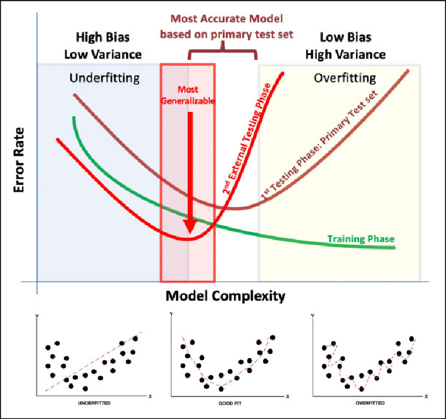

```python
from IPython.display import Image

Image(filename='./Images/BVT.png')
```

The bias-variance tradeoff is a fundamental concept in machine learning that refers to the balance that must be achieved between bias (error from erroneous assumptions in the learning algorithm) and variance (error from sensitivity to small fluctuations in the training set).

In other words, a model with high bias pays very little attention to the training data and oversimplifies the model. It always leads to high error on training and test data. On the other hand, a model with high variance pays a lot of attention to training data and does not generalize on the data which it hasn’t seen before. As a result, such models perform very well on training data but has high error rates on test data.

Mathematically, the bias-variance tradeoff is expressed as follows:

```python
Total Error = Bias^2 + Variance + Irreducible Error
```

Here's what each term represents:

1. **Bias^2**: This is the squared difference between the average prediction of our model and the correct value. High bias can cause an algorithm to miss the relevant relations between features and target outputs (underfitting).
2. **Variance**: This is the variability of a model prediction for a given data point. High variance can cause an algorithm to model the random noise in the training data, rather than the intended outputs (overfitting).
3. **Irreducible Error**: This is the inherent noise in the problem itself. This part of the error can't be reduced by any model.

The goal in selecting a model is to balance bias and variance, to minimize the total error. A highly flexible model will have low bias but high variance, while a less flexible model will have high bias but low variance. The challenge is finding the right level of model complexity that achieves a low total error.

# What are some common techniques for reducing bias and variance in machine learning models?

Reducing bias and variance in machine learning models often involves a trade-off, as decreasing one can increase the other. However, there are several techniques that can help manage this trade-off:

1. **Increasing Model Complexity**: If a model is too simple, it may have high bias. Adding more features, creating more complex relationships (like interaction terms or polynomial features), or using a more complex model can help reduce bias.
2. **Decreasing Model Complexity**: If a model is too complex, it may have high variance. Simplifying the model by removing features, using simpler relationships, or using a less complex model can help reduce variance.
3. **Regularization**: Techniques like L1 (Lasso) and L2 (Ridge) regularization add a penalty term to the loss function, which discourages overfitting by preventing the coefficients from becoming too large.
4. **Ensemble Methods**: Techniques like bagging and boosting can help reduce variance. Bagging (Bootstrap Aggregating) involves creating multiple subsets of the original data, training a model on each, and then averaging the predictions. Boosting trains models sequentially, each trying to correct the mistakes of the previous one.
5. **Cross-Validation**: This technique involves splitting the training data into several subsets and training the model on each subset. The average error across all subsets is used as the overall error. This helps in making the model more robust and less prone to overfitting.
6. **Increasing Training Data**: More data can help the model learn better and reduce both bias and variance. However, this may not always be feasible due to resource constraints.
7. **Feature Selection**: Removing irrelevant or redundant features can reduce variance by simplifying the model.
8. **Early Stopping**: In iterative algorithms like gradient descent, the training can be stopped early to prevent overfitting, thus reducing variance.

Remember, the goal is to find a balance between bias and variance that minimizes the total error.

# Explain Maximum Likelihood Estimation in ml?

Maximum Likelihood Estimation (MLE) is a method used in machine learning to estimate the parameters of a model. It works by finding the parameters that maximize the likelihood of the observed data given the parameters.

The likelihood of the observed data is a measure of how probable it is to observe the given data for different values of the parameters. The parameters that maximize this likelihood are considered to be the best and are chosen as the estimated parameters.

Mathematically, if we have a dataset X = {x1, x2, ..., xn} that are independently and identically distributed, and a model with parameters θ, the likelihood function L(θ; X) is given by:

```python
L(θ; X) = P(X; θ) = Π P(xi; θ)
```

where P(xi; θ) is the probability of observing xi given the parameters θ.

The goal of MLE is to find the parameters θ that maximize this likelihood function. In practice, it's often easier to maximize the log of the likelihood function, known as the log-likelihood, because the log of a product becomes a sum:

```python
l(θ; X) = log L(θ; X) = Σ log P(xi; θ)
```

The parameters θ that maximize the log-likelihood are the maximum likelihood estimates. These can be found using optimization algorithms like gradient descent.